# Using LP Duality to Measure Sensitivity of a Constrained Renewable Generation System

### Introduction

Given a closed system with a fixed hourly demand for electricity, the goal is to develop a generation portfolio from solar, wind, and dispatchable storage resources that will serve the supply while minimizing the total cost of the developing the mix of resources. At first, we develop an LP that minimizes total cost (and optimially dispatches the storage resources) while meeting every hourly demand. Then, we use duality theory to omit the hourly demand constraints that are the most costly to the system. This will allow us to derive a cost curve vs overall reliability of the system given a entirely renewable system.

### Primal Problem Formulation

For a given cost of generation capacity by resource, the model is formulated to minimize total capacity build out costs while meeting all hourly demand. For the storage resource, which is an important resource to help fill in the gaps between low wind and solar generation hours, there are hourly decision variables introduced (charge, discharge, and current level of stored energy) to model the optimal schedule.

Below shows the model formulation and code that leverages [PuLP](https://coin-or.github.io/pulp/index.html) as the modeling framework, and the python API for the [HiGHS](https://highs.dev/) open-source solver.

**Decision Variables**

$$c_\alpha = \text{capacity (kW) build-out for each resource } \alpha \in \text{{Solar, Wind, Storage}}$$$$x_i = \text{discharge (+) in kWh of storage resource for each hour } i$$$$y_i = \text{charge (-) in kWh of storage resource for each hour } i$$$$s_i = \text{state of charge (kWh) of storage resource for each hour } i $$

**Input Variables**

$$D_i = \text{electric demand (kWh) for each hour } i $$$$G_{i\beta} = \text{capacity factor for each hour } i \text{ and resource } \beta \in \text{{Solar, Wind}}$$$$E = \text{charge to discharge efficiency of storage resource}$$$$H = \text{number of hours of storage resource capability}$$$$C_\alpha = \text{cost of capacity (\$/kW) for each resource } \alpha \in \text{{Solar, Wind, Storage}}$$

**Objective Function**

$$\min \sum_\alpha C_\alpha c_\alpha$$

**Constraints**

$$G_{i\text{, solar}}c_\text{solar} + G_{i\text{, wind}}c_\text{wind} + x_i + y_i \geq D_i \; \forall i$$$$0 \leq s_i \leq H c_\text{storage} \; \forall i$$$$0 \leq x_i \leq c_\text{storage} \; \forall i$$$$-c_\text{storage} \leq y_i \leq 0 \; \forall i$$$$s_{i+1} = s_i - Ey_i - x_i \; \forall i$$$$s_0 = 0$$$$c_\alpha \geq 0 \; \forall \alpha$$

```python
from pulp import *
import highspy
import numpy as np
import pandas as pd
import matplotlib.pyplot as plt
```

```python
class Generation_System:
    def __init__(self, D, Gs, Gw, E, H, C):
        self.D = D
        self.Gs = Gs
        self.Gw = Gw
        self.E = E
        self.H = H
        self.C = C
        self.tightest_hours = []

    def set_hours_resource_sets(self):
        self.hours = range(len(self.D))
        self.resources = ["Solar", "Wind", "Storage"]
        self.C = len(str(len(self.hours)))

    def build_model(self):
        prob = LpProblem("Generation_System")

        self.hours_suffix = [str(i).zfill(self.C) for i in self.hours]
        c = LpVariable.dicts("Capacity", (self.resources), lowBound = 0)
        x = LpVariable.dicts("Discharge", (self.hours_suffix), lowBound = 0)
        y = LpVariable.dicts("Charge", (self.hours_suffix), upBound = 0)
        s = LpVariable.dicts("State_Of_Charge", (self.hours_suffix), lowBound = 0)

        # objective function
        prob += lpSum([C[a] * c[a] for a in self.resources])

        # demand constraints
        for i in self.hours:
            if i in self.tightest_hours:
                mult = 0
            else:
                mult = 1
            prob += (Gs[i] * c["Solar"] + Gw[i] * c["Wind"] + x[self.hours_suffix[i]] + y[self.hours_suffix[i]] >= D[i]*mult,
                    "Demand_For_Hour_%s" % (str(i).zfill(self.C)))

        # state of charge upper bound constraint
        for i in self.hours:
            prob += (s[self.hours_suffix[i]] <= H * c["Storage"], "SOC_Bound_For_Hour_%s" % (str(i).zfill(self.C)))

        # discharge upper bound constraint
        for i in self.hours:
            prob += (x[self.hours_suffix[i]] <= c["Storage"], "Discharge_For_Hour_%s" % (str(i).zfill(self.C)))

        # charge lower bound constraint
        for i in self.hours:
            prob += (-c["Storage"] <= y[self.hours_suffix[i]], "Charge_For_Hour_%s" % (str(i).zfill(self.C)))

        # state of charge constraints
        for i in self.hours[:-1]:
            prob += (s[self.hours_suffix[i+1]] == s[self.hours_suffix[i]] - E * y[self.hours_suffix[i]] - x[self.hours_suffix[i]], "SOC_For_Hour_%s" % (str(i).zfill(self.C)))
        prob += (s[self.hours_suffix[0]] == 0)

        #prob.writeLP("Generation_System.lp")
        prob.writeMPS("Generation_System.mps")

        self.model = prob

    def solve_model(self, print_sol = True):
        # optimize model
        h = highspy.Highs()
        h.readModel("Generation_System.mps")
        h.run()
        self.solution = h.getSolution()
        self.highs_info = h.getInfo()
        model_status = h.getModelStatus()
        self.highs_model = h
        self.obj_val = self.highs_info.objective_function_value
        self.tightest_hours.append(np.argmax(system.solution.row_dual[:len(self.hours)]))
        if print_sol:
            print("Model has status ", h.modelStatusToString(model_status))
            print()
            print('Optimal objective = $', round(self.obj_val, 2))
            print('Iteration count = ', self.highs_info.simplex_iteration_count)
            print()

    def get_results(self, print_sol = True):
        # print solution
        variables = self.solution.col_value
        self.var_names = (["Solar", "Storage", "Wind"] +
                          ["Charge_" + str(i) for i in self.hours] +
                          ["Discharge_" + str(i) for i in self.hours])
        self.var_values = {self.var_names[i]:round(variables[i],2) for i in range(len(self.hours)*2+3)}
        if print_sol:
            print("Solar, Storage, Wind Capacity = %s, %s, %s" % (self.var_values["Solar"],
                                                                  self.var_values["Storage"],
                                                                  self.var_values["Wind"]))

    def create_df(self, df):
        df["Solar_Gen"] = system.var_values["Solar"] * df["Solar_CF"]
        df["Wind_Gen"] = system.var_values["Wind"] * df["Wind_CF"]

        charge = []
        discharge = []
        for hour in range(len(D)):
            charge.append(system.var_values["Charge_" + str(hour)])
            discharge.append(system.var_values["Discharge_" + str(hour)])

        df["Charge"] = charge
        df["Discharge"] = discharge

        df["System_Net_Generation"] = df["Solar_Gen"] + df["Wind_Gen"] + df["Charge"] + df["Discharge"]
        self.df = df
```

For demonstration purposes and sensitivity analysis, we can define some generalized inputs. The solar and wind capacity costs are estimated from LAZARD’S LEVELIZED COST OF ENERGY ANALYSIS — VERSION 16.0, and the storage capacity costs are estimated from NREL [Cost Projections for Utility-Scale Battery Storage: 2023 Update](https://www.nrel.gov/docs/fy23osti/85332.pdf) battery costs. The efficiency of the storage resource is set to $90$%, and the number of hours of the storage resource is set to $4$. For example, a $20$ kW $4$-hour storage resource from full capacity can discharge $80$ kWh over the $4$-hour span.

```python
# inputs
E = 0.9
H = 4.0
C = {"Solar": (700+1400)/2, "Wind": (1025+1700)/2, "Storage": 482*H}
```

For a generic hourly profile of electricity demand, the 2023 full year of ERCOT [Hourly Load Data Archives](https://www.ercot.com/gridinfo/load/load_hist) is used. We treat the ERCOT system MWh demand as kWh, and furthermore divide by $1000$, so our system will be optimized to serve the proportionate of one-millionth of the ERCOT system hourly demand for all of 2023.

Since solar and wind resources are not dispatchable and depend on weather conditions, we leverage the [Hourly Aggregated Wind and Solar Output](https://www.ercot.com/mp/data-products/data-product-details?id=PG7-126-M) to derive proportionate hourly solar and wind output from $1$ kW of capacity, known as the capacity factor.

```python
df = pd.read_excel("ERCOT_2023_Hourly_WindSolar_Output.xlsx", sheet_name = "Wind Data")
df["Wind_CF"] = df["ERCOT.WIND.GEN"] / df["Total Wind Installed, MW"]
df = df[["Time (Hour-Ending)", "Date", "ERCOT.LOAD", "Wind_CF"]]

df_solar = pd.read_excel("ERCOT_2023_Hourly_WindSolar_Output.xlsx", sheet_name = "Solar Data")
df_solar["Solar_CF"] = df_solar["ERCOT.PVGR.GEN"] / df_solar["Total Solar Installed, MW"]

df = df.merge(df_solar[["Time (Hour-Ending)", "Solar_CF"]], how = "left")
df["ERCOT.LOAD"] = df["ERCOT.LOAD"] / 1_000
df["Month"] = df["Date"].dt.month

df = df.iloc[:-1]
```

### Running the Primal Model

```python
D = np.array(df["ERCOT.LOAD"])
Gs = np.array(df["Solar_CF"])
Gw = np.array(df["Wind_CF"])
```

```python
system = Generation_System(D, Gs, Gw, E, H, C)
system.set_hours_resource_sets()
system.build_model()
system.solve_model()
system.get_results()
system.create_df(df)
```

```
Model has status  Optimal

Optimal objective = $ 1160177.2
Iteration count =  18999

Solar, Storage, Wind Capacity = 26.61, 226.35, 510.7
```

The solver found an optimal solution for serving each hour's demand at a total cost of $\$1,160,177$ by building out approximately $27$ kW of solar, $226$ kW of storage, and $511$ kW of wind capacity.

Let's plot the hourly generation vs demand time series to see the relationship of how much over-generation is needed in most hours to compensate for the high-demand hours with low renewable capacity factors.

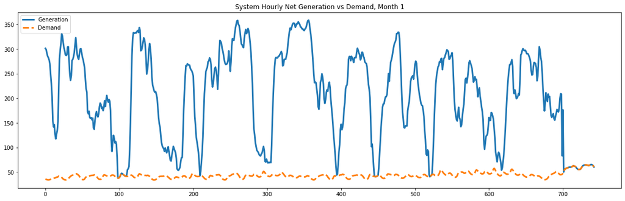

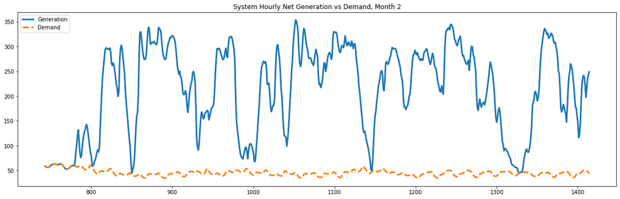

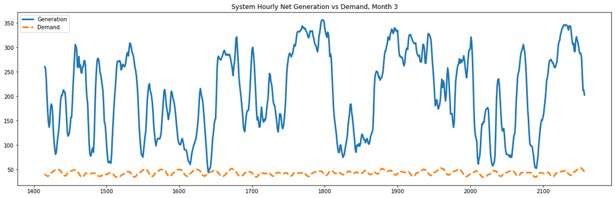

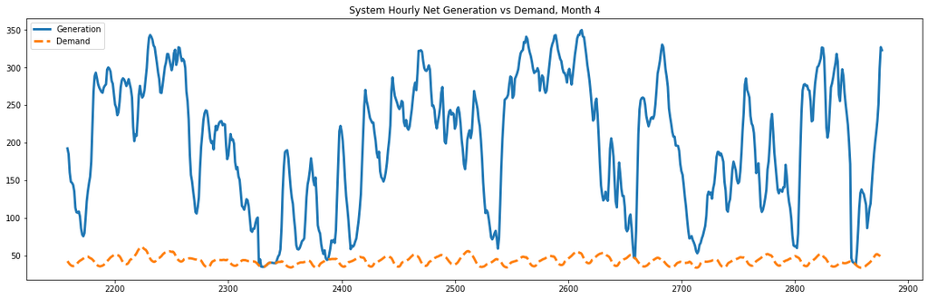

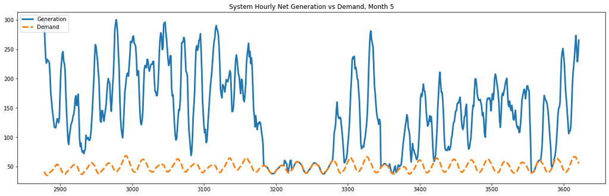

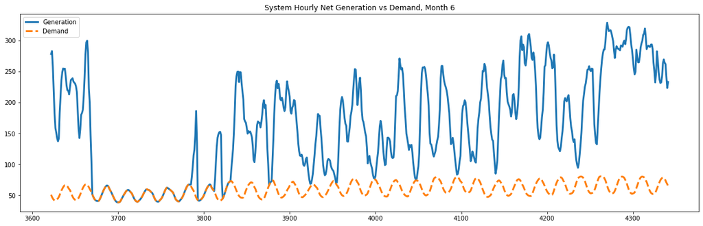

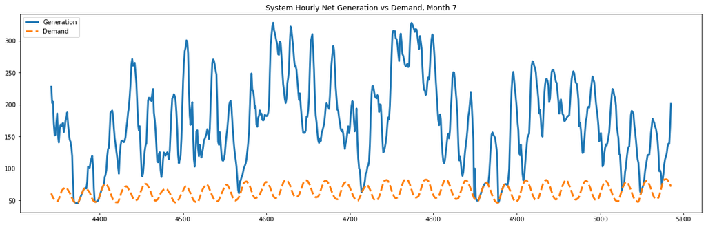

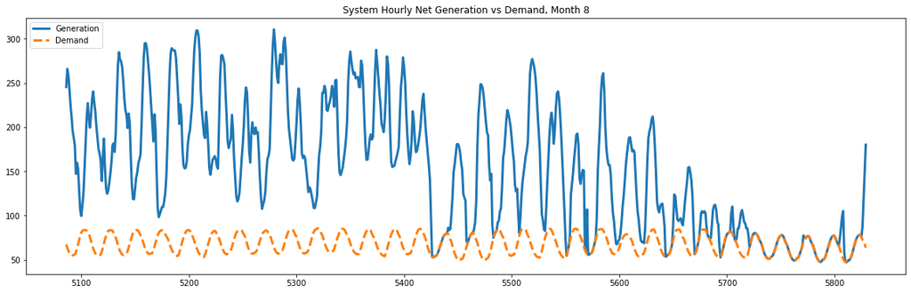

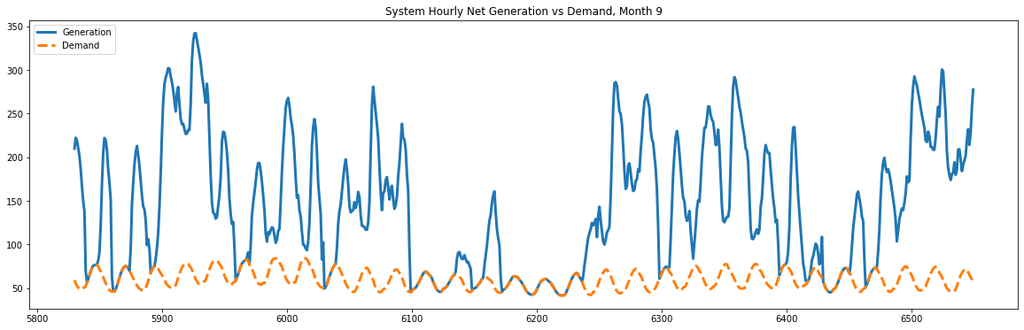

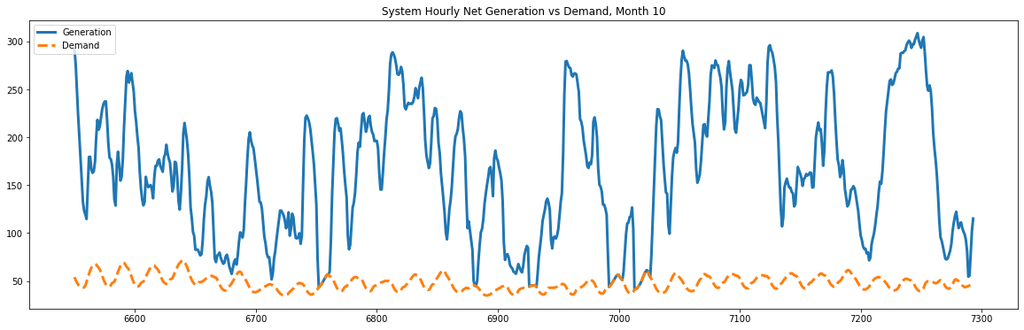

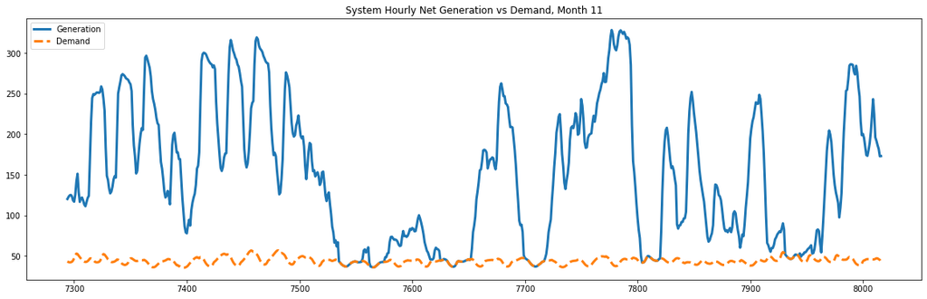

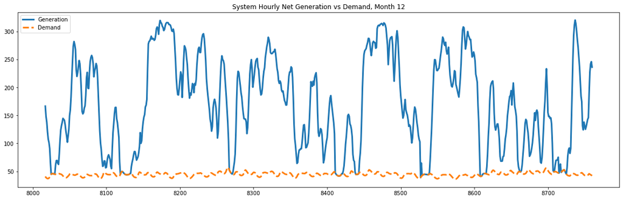

```python
plt.rcParams["figure.figsize"] = (20,6)

for m in range(1, 13):
    plt.plot(system.df[system.df["Month"] == m]["System_Net_Generation"], linewidth=3, label='Generation')
    plt.plot(system.df[system.df["Month"] == m]["ERCOT.LOAD"], linestyle="dashed", linewidth=3, label='Demand')
    plt.title("System Hourly Net Generation vs Demand, Month " + str(m))
    plt.legend(loc="upper left")
    plt.show()
```

Using the duality functionality built into the HiGHS API, we can return the dual values of each of the demand constraints. This gives us an idea of which constraints are binding and by how much a relaxation of the total demand requirement will improve the objective function. In this example, lets find the most costly hour and first plot a zoomed in view. Then, lets run the model again but omit the demand requirement on the tightest hour.

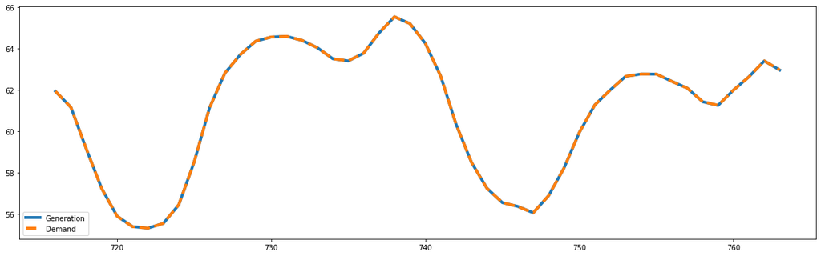

```
Model has status  Optimal

Optimal objective = $ 1154653.31
Iteration count =  18921

Solar, Storage, Wind Capacity = 32.18, 280.7, 425.45
```

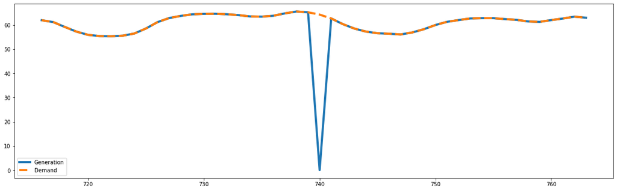

|  | Time (Hour-Ending) | Date | ERCOT.LOAD | Wind_CF | Solar_CF | Month | Solar_Gen | Wind_Gen | Charge | Discharge | System_Net_Generation |
| --- | --- | --- | --- | --- | --- | --- | --- | --- | --- | --- | --- |
| 735 | 2023-01-31 16:00:00 | 2023-01-31 | 63.417060 | 0.144146 | 0.066572 | 1 | 2.142290 | 61.326906 | -0.05 | 0.00 | 63.419195 |
| 736 | 2023-01-31 17:00:00 | 2023-01-31 | 63.789571 | 0.137793 | 0.038073 | 1 | 1.225195 | 58.623869 | 0.00 | 3.94 | 63.789064 |
| 737 | 2023-01-31 18:00:00 | 2023-01-31 | 64.768084 | 0.131590 | 0.011496 | 1 | 0.369950 | 55.984928 | 0.00 | 8.41 | 64.764878 |
| 738 | 2023-01-31 19:00:00 | 2023-01-31 | 65.551844 | 0.127287 | 0.000108 | 1 | 0.003487 | 54.154282 | 0.00 | 11.39 | 65.547770 |
| 739 | 2023-01-31 20:00:00 | 2023-01-31 | 65.219214 | 0.128885 | 0.000016 | 1 | 0.000506 | 54.834041 | 0.00 | 10.39 | 65.224547 |
| 740 | 2023-01-31 21:00:00 | 2023-01-31 | 64.263484 | 0.116118 | 0.000015 | 1 | 0.000498 | 49.402210 | -49.40 | 0.00 | 0.002708 |
| 741 | 2023-01-31 22:00:00 | 2023-01-31 | 62.672159 | 0.106319 | 0.000016 | 1 | 0.000518 | 45.233627 | 0.00 | 17.44 | 62.674145 |
| 742 | 2023-01-31 23:00:00 | 2023-01-31 | 60.340351 | 0.088562 | 0.000016 | 1 | 0.000503 | 37.678504 | 0.00 | 22.66 | 60.339007 |
| 743 | 2023-02-01 00:00:00 | 2023-02-01 | 58.498857 | 0.096731 | 0.000018 | 2 | 0.000565 | 41.154293 | 0.00 | 17.34 | 58.494858 |
| 744 | 2023-02-01 01:00:00 | 2023-02-01 | 57.245411 | 0.107783 | 0.000017 | 2 | 0.000557 | 45.856229 | 0.00 | 11.39 | 57.246786 |

```python
plt.plot(system.df.iloc[(system.tightest_hours[0]-24):(system.tightest_hours[0]+24)]["System_Net_Generation"], linewidth=4, label='Generation')
plt.plot(system.df.iloc[(system.tightest_hours[0]-24):(system.tightest_hours[0]+24)]["ERCOT.LOAD"], linestyle="dashed", linewidth=4, label='Demand')
plt.legend(loc="lower left")
plt.show()

system.build_model()
system.solve_model()
system.get_results()
system.create_df(df)

plt.plot(system.df.iloc[(system.tightest_hours[0]-24):(system.tightest_hours[0]+24)]["System_Net_Generation"], linewidth=4, label='Generation')
plt.plot(system.df.iloc[(system.tightest_hours[0]-24):(system.tightest_hours[0]+24)]["ERCOT.LOAD"], linestyle="dashed", linewidth=4, label='Demand')
plt.legend(loc="lower left")
plt.show()

display(df.iloc[(system.tightest_hours[0]-5):(system.tightest_hours[0]+5)])
```

It can be seen that by removing the demand requirement for hour $740$ lowers the system cost by about $0.5$% to $\$1,154,653$ even though that hour only represents about $0.01$% of the total hours. It is also notable that the wind capacity dropped significantly bolstered by moderate increases in solar and storage capacity. The dataframe of results shows us that since the model no longer is constrained to supply the demand for hour $740$, the total renewable output for that hour goes to storage to prepare for the subsequent tighe hours, hence netting zero generation (or the equivalent of a system blackout) for hour $740$.

```python
obj_values = []

system = Generation_System(D, Gs, Gw, E, H, C)
system.set_hours_resource_sets()

for i in range(100):
    system.build_model()
    system.solve_model(print_sol = False)
    system.get_results(print_sol = False)
    obj_values.append(system.obj_val)
```

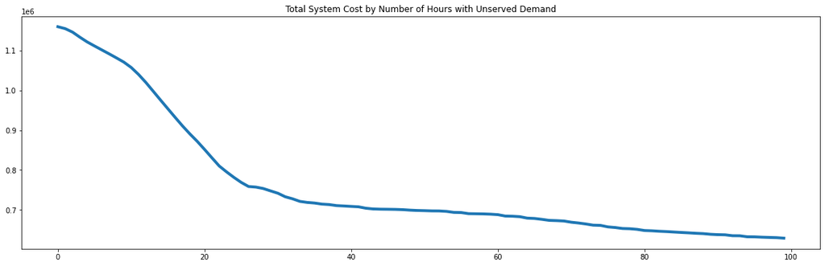

```python
plt.plot(obj_values, linewidth=4)
plt.title("Total System Cost by Number of Hours with Unserved Demand")
plt.show()
```